# Kolleg Europa - Network Analysis

Beispiel: Affiliationsnetzwerke

Stefan Haussner

6 März 2019

# Affiliationsnetzwerke

Alle Netzwerke, die wir bisher untersucht haben, basieren auf direkten Verbindungen. Das heißt, die sozialen Bindungen, die die Akteure im sozialen Netzwerk verbinden, wurden durch Selbstbericht, direkte Beobachtung oder eine andere Art von Datenerhebung bestätigt. Sozialwissenschaftler sind jedoch häufig an Situationen interessiert, in denen diese sozialen Beziehungen nicht direkt beobachtet werden können.

Allerdings können wir davon ausgehen, dass auch Akteure, welche sich in den selben Situationen oder an den selben Orten befinden, die Möglichkeit einer Verbindung aufweisen. Beispielsweise können wir eine Verbindung zwischen Eliten annehmen, die sich in den gleichen Vorständen befinden oder Sportlerinnen in den gleichen Vereinen.

Wir nennen diesen neuen Typ eines sozialen Netzwerks ein Affiliationsnetzwerk. Ein Affiliationsnetzwerk ist ein Netzwerk, in dem die Mitglieder aufgrund einer Co-Mitgliedschaft in einer Gruppe oder einer Mitbeteiligung an einer Veranstaltung miteinander verbunden sind.

```r
C1 <- c(1,1,1,0,0,0)
C2 <- c(0,1,1,1,0,0)
C3 <- c(0,0,1,1,1,0)
C4 <- c(0,0,0,0,1,1)
aff_df <- data.frame(C1,C2,C3,C4)
row.names(aff_df) <- c("S1","S2","S3","S4","S5","S6")

aff_df
```

```
##    C1 C2 C3 C4
## S1  1  0  0  0
## S2  1  1  0  0
## S3  1  1  1  0
## S4  0  1  1  0
## S5  0  0  1  1
## S6  0  0  0  1
```

Diese Art von Datenmatrix wird als Inzidenzmatrix bezeichnet und zeigt, wie n Akteure zu g Gruppen gehören. In diesem Fall haben wir bspw. sechs Schüler, die in vier Klassen eingeteilt sind. Eine Inzidenzmatrix ähnelt einer Adjazenzmatrix, aber eine Adjazenzmatrix ist immer eine eine n*n-Quadratmatrix, in der sich jede Dimension auf die Akteure im Netzwerk bezieht. Eine Inzidenzmatrix dagegen ist eine rechteckige Matrix mit zwei verschiedenen Dimensionen: Akteure und Gruppen. Aus diesem Grund werden Affiliationsnetzwerke auch als Two-Mode-Netzwerke, bipartite Netzwerke oder Zugehörigkeitsnetzwerke bezeichnet.

In Zugehörigkeitsnetzwerken gibt es immer zwei Arten von Knoten: einen Typ für die Akteure und einen anderen Typ für die Gruppen oder Ereignisse, zu denen die Akteure gehören. Eine Verbindung ergibt sich dann immer zwischen einem Akteur und einem Ereignis. Eine Folge davon ist, dass es keine direkten Verbindungen zwischen den Akteuren und keine direkten Verbindungen zwischen den Gruppen/Ereignissen gibt.

# Exkurs: Hollywood als Affiliationsnetzwerk

Wir nutzen in diesem Beispiel den Datensatz hwd.[^1]

Der hwd-Datensatz enthält ein Affiliationsnetzwerk, mit dem die Technik verdeutlicht werden kann. hwd steht mutmaßlich für Hollywood Data: Schauspieler sind durch die Filme miteinander verbunden, in denen sie zusammen auftreten. Das hwd-Dataset ist ein zweigeteiltes Graph-Objekt von igraph. Die Daten stammen ursprünglich von IMDB (www.imdb.com). Der Datensatz enthält die zehn beliebtesten Filme (von IMBD-Nutzern bewertet) für jedes Jahr von 1999 bis 2014 und die ersten zehn Schauspieler, die auf der IMDB-Seite jedes Films aufgeführt sind. Zusätzlich zu den Film- und Schauspielernamen hat jeder Film das Jahr seiner Veröffentlichung, seine IMDB-Benutzerbewertung und die MPAA-Filmbewertung (d. H. G, PG, PG-13 und R) als Knoteneigenschaft gespeichert.

## Daten einlesen

```r
load("../data/hwd.rda")

hwd
```

```
## IGRAPH 9cdab39 UN-B 1365 1600 --
## + attr: name (v/c), type (v/l), year (v/n), IMDBrating (v/n),
## | MPAArating (v/c)
## + edges from 9cdab39 (vertex names):
##  [1] Inception          --Leonardo DiCaprio
##  [2] Inception          --Joseph Gordon-Levitt
##  [3] Inception          --Ellen Page
##  [4] Inception          --Tom Hardy
##  [5] Inception          --Ken Watanabe
##  [6] Inception          --Dileep Rao
##  [7] Inception          --Cillian Murphy
## + ... omitted several edges
```

```r
V(hwd)$name[1:10]
```

```
##  [1] "Inception"
##  [2] "Alice in Wonderland"
##  [3] "Kick-Ass"
##  [4] "Toy Story 3"
##  [5] "How to Train Your Dragon"
##  [6] "Despicable Me"
##  [7] "Scott Pilgrim vs. the World"
##  [8] "Hot Tub Time Machine"
##  [9] "Harry Potter and the Deathly Hallows: Part 1"
## [10] "Tangled"
```

```r
V(hwd)$IMDBrating[1:10]
```

```
##  [1] 8.8 6.5 7.8 8.4 8.2 7.7 7.5 6.5 7.7 7.9
```

In der ersten Zeile der Ausgabe des Datensatzes erkennen wir, dass das Objekt ein IGRAPH-Objekt ist (Paket zur Netzwerkanalyse in R). UN-B zeigt an, dass es ein bipartites Netzwerk ist. UN = Undirected; B = Bipartit. Es gibt insgesamt 1365 Knoten und 1600 Kanten/Verbindungen.

Darunter sind die Verbindungen zu sehen, bspw. Inception und Leonardo DiCaprio. Der Datensatz enthält ebenso verschiedene zusätzliche Attribute, von denen wir uns ebenfalls bspw. die ersten 10 Elemente ausgeben lassen können. Die ersten Elemente des Netzwerks sind offenbar die Filme.

## erster Blick ins Netzwerk (oder Untergruppen davon)

Bei bipartiten Igraph-Objekten ist – außer man benennt das Attribut selbst – ein type-Attribut vorhanden. Dieses kann die Zustände TRUE oder FALSE annehmen und zeigt an, ob das Element zu der Gruppe der Akteure oder der “Ereignisse” gehört.

```r
V(hwd)$type[1:10]
```

```
##  [1] TRUE TRUE TRUE TRUE TRUE TRUE TRUE TRUE TRUE TRUE
```

```r
V(hwd)$type[155:165]
```

```
##  [1]  TRUE  TRUE  TRUE  TRUE  TRUE  TRUE FALSE FALSE FALSE FALSE FALSE
```

```r
cbind(V(hwd)$type[155:165], V(hwd)$name[155:165])
```

```
##       [,1]    [,2]
##  [1,] "TRUE"  "Notting Hill"
##  [2,] "TRUE"  "Eyes Wide Shut"
##  [3,] "TRUE"  "The Green Mile"
##  [4,] "TRUE"  "10 Things I Hate About You"
##  [5,] "TRUE"  "American Pie"
##  [6,] "TRUE"  "Girl, Interrupted"
##  [7,] "FALSE" "Leonardo DiCaprio"
##  [8,] "FALSE" "Joseph Gordon-Levitt"
##  [9,] "FALSE" "Ellen Page"
## [10,] "FALSE" "Tom Hardy"
## [11,] "FALSE" "Ken Watanabe"
```

Vorteil des igraph-packages. Kann “grafische” Informationen direkt im Netzwerk-Objekt selbst speichern. Hier wird jetzt die Information, wie der Knoten dargestellt werden soll, direkt abhängig vom type mitgegeben. Auch die Farbe wird abhängig vom type festgelegt.

```r
V(hwd)$shape <- ifelse(V(hwd)$type==TRUE,
                      "square","circle")

V(hwd)$shape[155:165]
```

```
##  [1] "square" "square" "square" "square" "square" "square" "circle"
##  [8] "circle" "circle" "circle" "circle"
```

```r
V(hwd)$color <- ifelse(V(hwd)$type==TRUE,
"red","lightblue")

cbind(V(hwd)$name[155:165], V(hwd)$shape[155:165], V(hwd)$color[155:165])
```

```
##       [,1]                         [,2]     [,3]
##  [1,] "Notting Hill"               "square" "red"
##  [2,] "Eyes Wide Shut"             "square" "red"
##  [3,] "The Green Mile"             "square" "red"
##  [4,] "10 Things I Hate About You" "square" "red"
##  [5,] "American Pie"               "square" "red"
##  [6,] "Girl, Interrupted"          "square" "red"
##  [7,] "Leonardo DiCaprio"          "circle" "lightblue"
##  [8,] "Joseph Gordon-Levitt"       "circle" "lightblue"
##  [9,] "Ellen Page"                 "circle" "lightblue"
## [10,] "Tom Hardy"                  "circle" "lightblue"
## [11,] "Ken Watanabe"               "circle" "lightblue"
```

Für den ersten Plot werden wir uns einen Teil der Martin Scorsese-Filme ansehen, die in den letzten 15 Jahren veröffentlicht wurden. In diesem Beispiel wird auch veranschaulicht, wie ein Subgraph erstellt wird, indem nur die Kanten extrahiert werden, die Knoten mit bestimmten Eigenschaften aufweisen (in diesem Fall wird der Subgraph auf der Basis des Namens von Scorsese-Filmen gefiltert). Der Schlüssel ist hier die spezielle Funktion E() um die Kanten (Edges) zu filtern.

Die resultierende Grafik unterstreicht die besondere Rolle von Leonardo DiCaprio in diesen Scorsese-Filmen. Er ist der einzige Schauspieler, der in allen drei Filmen eine der Hauptrollen spielt.

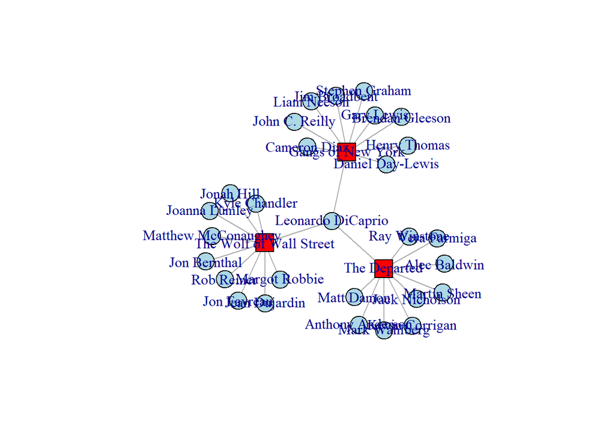

```r
movie_selection <- c("The Wolf of Wall Street", "Gangs of New York","The Departed")

hwd_leo <- subgraph.edges(hwd, E(hwd)[inc(V(hwd)[name %in% movie_selection])])
plot(hwd_leo, layout = layout_with_kk)
```

Was kann man aus dem gesamten Hollywood-Netzwerk lernen? Die meisten deskriptiven Netzwerkstatistiken können auf Affiliationsnetzwerke angewendet werden, aber sie müssen oft angepasst werden, entweder wie sie erstellt werden oder wie sie interpretiert werden. Zum Beispiel kann die Gesamtdichte des Zugehörigkeitsnetzwerks leicht berechnet werden, es ist jedoch nicht sehr aussagekräftig. Jeder Akteur ist per Definition mit einem Film verbunden zwischen den Filmen oder Schauspielern können keine direkten Verbindungen bestehen. Die Dichte des Graphs ist also von vorherein limitiert.

```r
graph.density(hwd)
```

```
## [1] 0.001718711
```

Stattdessen kann der individuelle Grad von Knoten informativer sein. In diesem Fall gilt das nur für die Schauspieler*innen, da jeder Film einen Grad von 10 besitzt (erste 10 aufgeführte Schauspieler*innen). Die degree-Funktion ermöglicht die Angabe, welche Knoten eingeschlossen werden sollen, um nur die Schauspieler*innen auszuwählen (für die der type FALSE ist).

```r
table(degree(hwd,v=V(hwd)[type==FALSE]))
```

```
##
##   1   2   3   4   5   6   7   8
## 955 165  47  23  11   2   1   1
```

```r
mean(degree(hwd,v=V(hwd)[type==FALSE]))
```

```
## [1] 1.327801
```

Dies zeigt, dass die große Mehrheit der Schauspieler nur in einem Film auftrat, aber es gab 15 Schauspieler, die seit 1999 in fünf oder mehr Filmen mitgespielt haben. Bei allen Schauspielern spielten sie durchschnittlich 1,3 Filme. Diese Informationen können dann verwendet werden, um die am stärksten besetzten Akteure der letzten eineinhalb Jahrzehnte zu identifizieren.

```r
V(hwd)$deg <- degree(hwd)
V(hwd)[type==FALSE & deg > 4]$name
```

```
##  [1] "Leonardo DiCaprio" "Emma Watson"       "Richard Griffiths"
##  [4] "Harry Melling"     "Daniel Radcliffe"  "Rupert Grint"
##  [7] "James Franco"      "Ian McKellen"      "Martin Freeman"
## [10] "Bradley Cooper"    "Christian Bale"    "Samuel L. Jackson"
## [13] "Natalie Portman"   "Brad Pitt"         "Liam Neeson"
```

```r
busy_actor <- data.frame(cbind(
  Actor = V(hwd)[type==FALSE & deg > 4]$name,
  Movies = V(hwd)[type==FALSE & deg > 4]$deg)) %>%
  as_tibble()

busy_actor %>%
  arrange(desc(Movies))
```

```
## # A tibble: 15 x 2
##    Actor             Movies
##    <fct>             <fct>
##  1 Daniel Radcliffe  8
##  2 Christian Bale    7
##  3 Leonardo DiCaprio 6
##  4 Emma Watson       6
##  5 Richard Griffiths 5
##  6 Harry Melling     5
##  7 Rupert Grint      5
##  8 James Franco      5
##  9 Ian McKellen      5
## 10 Martin Freeman    5
## 11 Bradley Cooper    5
## 12 Samuel L. Jackson 5
## 13 Natalie Portman   5
## 14 Brad Pitt         5
## 15 Liam Neeson       5
```

[figure not shown]

[figure not shown]

Hier könnte man jetzt noch einiges mehr machen. Das bringt uns in unserem Beispiel aber nicht weiter und nutzt eigentlich auch nicht wirklich die Möglichkeiten eines bipartiten Netzwerks. Bisher könnten man diese Erkenntnisse ja auch quasi mit deskriptiver Statistik ermitteln. Damit man auch wieder die allgemeinen statistischen Berechnungen für soziale Netzwerkanalyse anwenden kann, muss das bipartite Netzwerk in zwei Projektionen zerlegt werden.

## Analysis of the Actor and Movie Projections

Projektionen des bipartiten Netzwerks nennt man die zwei Teilnetzwerke, die aus dem bipartiten Netz entstehen. Auf diese Weise entsteht ein Schauspielernetzwerk, in dem Schauspieler miteinander verbunden sind, wenn sie zusammen in demselben Film mitgespielt haben, und ein Filmnetzwerk, in dem die Filme miteinander verbunden sind, wenn sie dieselben Schauspieler teilen. Die Akteurprojektion hat somit 1.205 Knoten und das Filmprojektionsnetzwerk 160 Knoten.

Im `igraph-Paket` geht das ohne großen Aufwand durch die Funktion `bipartite.projection()`. Wenn das igraph-Objekt das type-Attribut hat, geht das ohne weitere Argumente. Ist das bipartite Netzwerk durch etwas anderes als `type` strukturiert, lässt sich das auch über ein zusätzliches Argument mitgeben.

```r
hwd_pr <- bipartite.projection(hwd)
hwd_act <- hwd_pr$proj1
hwd_mov <- hwd_pr$proj2
hwd_act
```

```
## IGRAPH 7e9522e UNW- 1205 6903 --
## + attr: name (v/c), year (v/n), IMDBrating (v/n), MPAArating
## | (v/c), shape (v/c), color (v/c), deg (v/n), weight (e/n)
## + edges from 7e9522e (vertex names):
##  [1] Leonardo DiCaprio--Joseph Gordon-Levitt
##  [2] Leonardo DiCaprio--Ellen Page
##  [3] Leonardo DiCaprio--Tom Hardy
##  [4] Leonardo DiCaprio--Ken Watanabe
##  [5] Leonardo DiCaprio--Dileep Rao
##  [6] Leonardo DiCaprio--Cillian Murphy
##  [7] Leonardo DiCaprio--Tom Berenger
## + ... omitted several edges
```

```r
hwd_mov
```

```
## IGRAPH 7e9522e UNW- 160 472 --
## + attr: name (v/c), year (v/n), IMDBrating (v/n), MPAArating
## | (v/c), shape (v/c), color (v/c), deg (v/n), weight (e/n)
## + edges from 7e9522e (vertex names):
##  [1] Inception--The Wolf of Wall Street
##  [2] Inception--Django Unchained
##  [3] Inception--The Departed
##  [4] Inception--Gangs of New York
##  [5] Inception--Catch Me If You Can
##  [6] Inception--The Dark Knight Rises
##  [7] Inception--10 Things I Hate About You
## + ... omitted several edges
```

In dieser Abbildung wird das gesamte Filmnetzwerk dargestellt, wobei die Knotengröße auf der IMDB-Bewertung basiert, sodass populärere Filme größere Knoten haben.

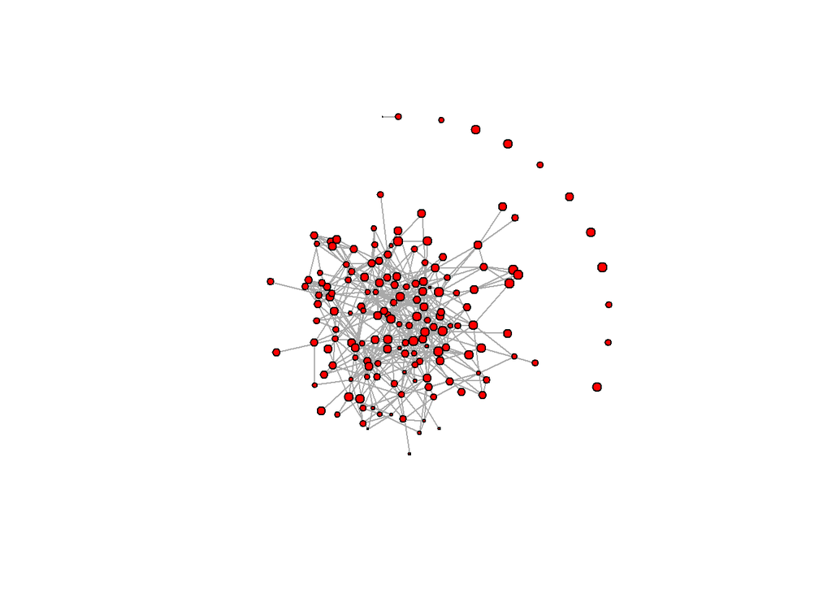

```r
plot(hwd_mov,
     vertex.color="red",
     vertex.shape="circle",
     vertex.size=(V(hwd_mov)$IMDBrating)-3,
     vertex.label=NA)
```

Einige deskriptive Netzwerkcharakteristika bieten weitere Informationen zum Hollywood-Filmenetzwerk. Obwohl es einige isolierte Filme gibt (d.h. Filme, die keine Schauspieler mit anderen Filmen teilen), bilden die meisten (148) der Filme, eine große verbundene Komponente.

```r
graph.density(hwd_mov)
```

```
## [1] 0.03710692
```

```r
no.clusters(hwd_mov)
```

```
## [1] 12
```

```r
clusters(hwd_mov)$csize
```

```
##  [1] 148   1   1   1   1   1   1   2   1   1   1   1
```

```r
table(E(hwd_mov)$weight)
```

```
##
##   1   2   3   4   5   6   7  10
## 411  21  12  16   6   1   2   3
```

Das gesamte Filmenetzwerk kann gefiltert werden, um die einzelnen großen verbundenen Komponenten zu untersuchen. In der nächsten Abbildung wurde die Kantenbreite so eingestellt, dass sie der Quadratwurzel des Gewichtskantenattributs entspricht. Dies führt dazu, dass die Beziehungen zwischen Filmen, in denen mehr Schauspieler vorhanden sind, stärker sind.

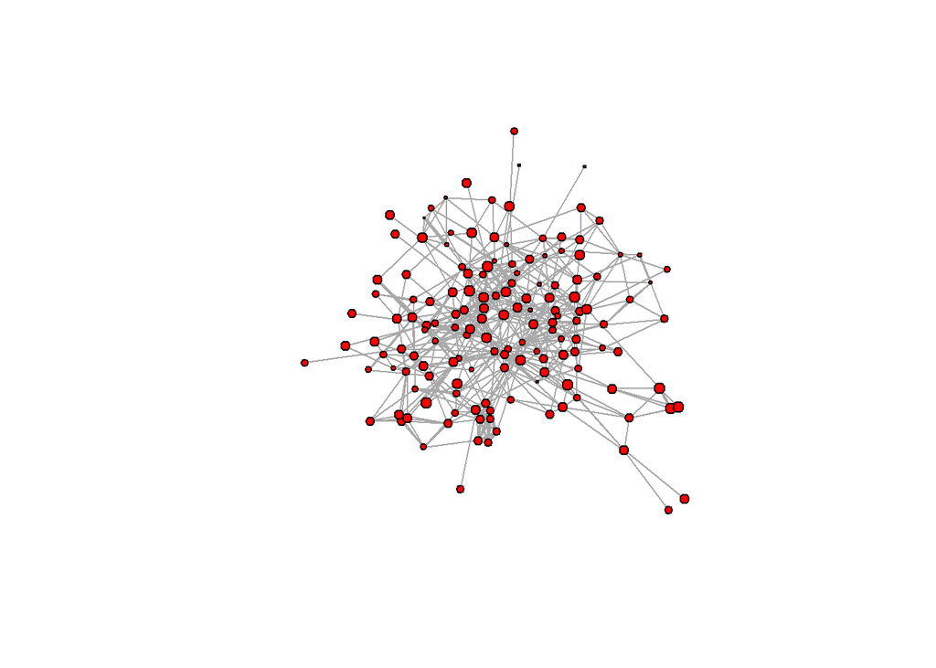

```r
hwd_mov2 <- induced.subgraph(hwd_mov,
                             vids=clusters(hwd_mov)$membership==1)

plot(hwd_mov2,
     vertex.color="red",
     edge.width=sqrt(E(hwd_mov)$weight),
     vertex.shape="circle",
     vertex.size=(V(hwd_mov2)$IMDBrating)-3,
     vertex.label=NA)
```

Die vorherige Abbildung ist immer noch groß und die relativ hohe Dichte macht die Interpretation interessanter Strukturmerkmale etwas schwierig. Um dies zu erleichtern, können wir die Cluster mit höherer Dichte des Netzwerks identifizieren und diese verwenden, um den stärker miteinander verbundenen Teil des Netzwerks zu vergrößern.

```r
table(graph.coreness(hwd_mov2))
```

```
##
##  1  2  3  4  5  6  7
## 11  5 23 65 29  7  8
```

```r
hwd_mov3 <- induced.subgraph(hwd_mov2,
                           vids=graph.coreness(hwd_mov2)>4)
hwd_mov3
```

```
## IGRAPH 7efde78 UNW- 44 158 --
## + attr: name (v/c), year (v/n), IMDBrating (v/n), MPAArating
## | (v/c), shape (v/c), color (v/c), deg (v/n), weight (e/n)
## + edges from 7efde78 (vertex names):
## [1] Alice in Wonderland                      --Hot Tub Time Machine
## [2] Hot Tub Time Machine                     --The Interview
## [3] The Hobbit: The Battle of the Five Armies--The Hobbit: The Desolation of Smaug
## [4] Inception                                --The Wolf of Wall Street
## [5] Exodus: Gods and Kings                   --American Hustle
## [6] Hot Tub Time Machine                     --This Is the End
## + ... omitted several edges
```

```r
unique(V(hwd_mov3)$name)
```

```
##  [1] "Inception"
##  [2] "Alice in Wonderland"
##  [3] "Hot Tub Time Machine"
##  [4] "Harry Potter and the Deathly Hallows: Part 1"
##  [5] "The Interview"
##  [6] "The Hobbit: The Battle of the Five Armies"
##  [7] "Exodus: Gods and Kings"
##  [8] "The Hobbit: The Desolation of Smaug"
##  [9] "The Wolf of Wall Street"
## [10] "American Hustle"
## [11] "This Is the End"
## [12] "The Hobbit: An Unexpected Journey"
## [13] "Django Unchained"
## [14] "The Dark Knight Rises"
## [15] "Harry Potter and the Deathly Hallows: Part 2"
```

[output cut: 29 more lines]

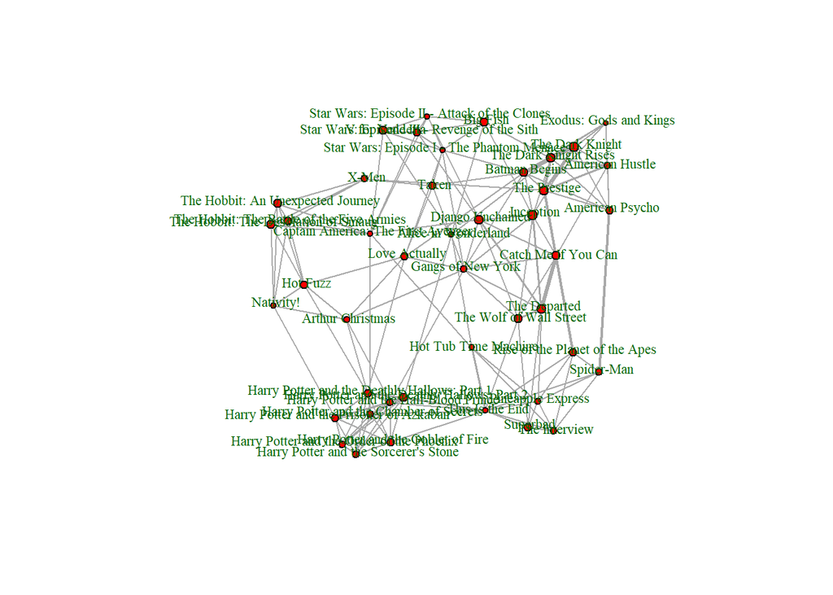

```r
plot(hwd_mov3,
     vertex.color="red",
     vertex.shape="circle",
     edge.width=sqrt(E(hwd_mov)$weight),
     vertex.label.cex=0.7,vertex.label.color="darkgreen",
     vertex.label.dist=0.3,
     vertex.size=(V(hwd_mov3)$IMDBrating)-3)
```

Dieses Netzwerk ist dann klein genug, dass wir Knotenbezeichnungen hinzufügen können, um die Interpretation zu erleichtern. Dies hilft uns zu erkennen, dass die am engsten verbundenen Bereiche des Netzwerks mit populären Filmserien korrespondieren, insbesondere Harry Potter, Batman, Star Wars und The Hobbit. Dies ist logisch, da Filme einer Serie natürlich viele oder die meisten der gleichen Schauspieler teilen.

[^1]: Ursprünglich war dieser im UserNetR-Paket zu finden. Da dieses Paket nicht mehr geupdated wird, wurde der Datensatz selber aus dem GitHub-Repo (https://github.com/DougLuke/UserNetR) geladen und hier lokal zur Verfügung gestellt.